# 687_Modelo

# Marco metodológico

## Consistencia interna

En los casos donde todas las variables son mediciones indirectas distintas de un mismo aspecto no medible, se hace referencia a la propiedad denominada consistencia interna. La consistencia interna consiste en la propiedad de las variables en estar altamente correlacionadas entre sí, lo que indica que están asociadas a un trazo latente. Dado que esta consistencia interna se encuentra reflejada en a estructura de correlación de las variables es posible medirla y analizarla. El Alfa de Cronbach (Cronbach, 1951) es una de las medidas más usadas para analizar la consistencia entre variables.

Dados $K$ variables $Y_1, Y_2, ..., Y_K$ y su suma $X = Y_1 + Y_2 + ... + Y_K$, el Alfa de Chronbach está dado por la expresión

$$\alpha = \frac{K}{K-1} \left(1-\frac{\sum_{i = 1}^K \sigma^2_{Y_i}}{\sigma^2_X}\right)$$

## Análisis de componentes principales

El Análisis de Componentes Principales (ACP) (Jolliffe, 2002) consiste en utilizar herramientas de álgebra lineal para reducir la dimensión de los datos. Cada registro de una base de datos es visto como un punto en el espacio vectorial $p$-dimensional; mediante una traslación y una rotación óptimas la nube de puntos es reubicada en un subespacio de dimensión menor con una pérdida mínima de información.

Este subespacio queda expresado en un número menor de dimensiones $p'$ representadas por sus respectivos ejes. La inercia se distribuye en estos ejes de manera descendente; así, el primer eje recoge la mayor cantidad de inercia lineal presente en la nube de puntos, el segundo la mayor cantidad restante, etc. Cada ejercicio arroja una tabla denominada tabla de autovalores que muestra la cantidad de inercia recogida por cada eje, tanto de manera absoluta como porcentual. Los planos construidos a partir de estos ejes mapean la nube de puntos guardando la mayor cantidad de información posible.

## Software

Para el proceso de recolección de datos fue utilizado MS Excel y el análisis de los mismos se realizó utilizando el software estadístico R (R Core Team, 2019).

# Análisis de los constructos

El primer paso en la construcción de un modelo de ecuaciones estructurales es el análisis de cada uno de los constructos.

En este sentido, se presenta apra cada constructo un análisis multivariado compuesto por 3 procedimientos.

Un análisis de correlación mútiple estudia las correlaciones entre los ítems a nivel individual mediante la matriz de correlaciones y a nivel grupal mediante un análisis factorial exploratorio, en este caso de componentes principales. En caso de inconvenientes en torno a las correlaciones es necesario modificar la estructura del constructo retirando ítems y luego realizar un análisis factorial confirmatorio.

Un análisis de consistencia interna de los ítems revela el nivel de consistencia de cada uno de los constructos. Para esto se calculan los estadísticos de alpha de Cronbach y lambda 6 de Guttman.

Un análisis de normalidad permite establecer si el constructo cumple o no el supuesto de normalidad.

Los resultados se encuentran en la tabla

Tabla: Estadísticos correspondientes a los constructos evaluados. CI: Cantidad de ítems; Var ACP: Porcentaje de varianza retenida por el primer eje en un ACP; Cron: Alpha de Cronbach; Gutt: Lambda 6 de Guttman; Shapiro: p-valor de la prueba de normalidad de Shapiro Wilks; Lilliefors: p-valor de la prueba de normalidad de Lilliefors. Fuente: elaboración propia.

| Rótulo | Nombre | CI | Var ACP | Cron | Gutt | Shapiro | Lilliefors |
| --- | --- | --- | --- | --- | --- | --- | --- |
| SI | Identidad social | 6 | 62.87 | 0.88 | 0.98 | 0.17 | 0.00 |
| BI | Identificación con la marca | 5 | 79.78 | 0.93 | 0.93 | 0.01 | 0.01 |
| BCI | Identificación de la comunidad de marca | 6 | 84.13 | 0.96 | 0.96 | 0.01 | 0.00 |
| e_WOM | Voz a voz electrónico | 4 | 89.80 | 0.96 | 0.95 | 0.00 | 0.00 |

### Identidad social

A continuación se muestra el análisis realizado a los ítems asociadas al constructo de Identidad social[^1].

#### Análisis de correlación múltiple

La matriz de correlaciones entre los ítems constituye una primera aproximación. En este gráfico es importante encontrar correlaciones fuertes entre los ítems, al menos mayores a 0.5.

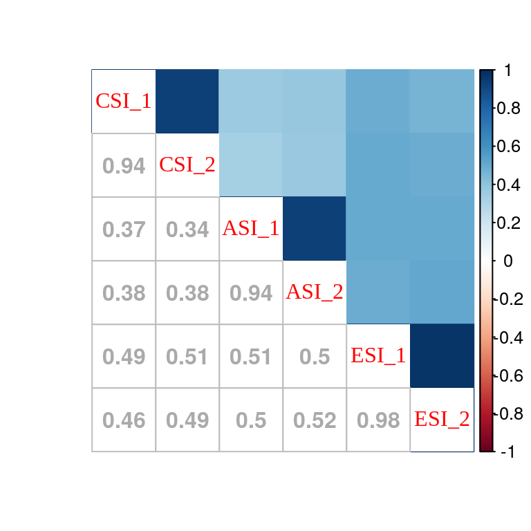

Figura: Matriz de correlaciones de *Identidad social*. Fuente: elaboración propia utilizando el software estadístico R (R Core Team, 2019).

En el análisis de componentes principales cada eje retiene un porcentaje de la varianza. Este es mostrado de manera individual y acumulada en el gráfico de sedimentación.

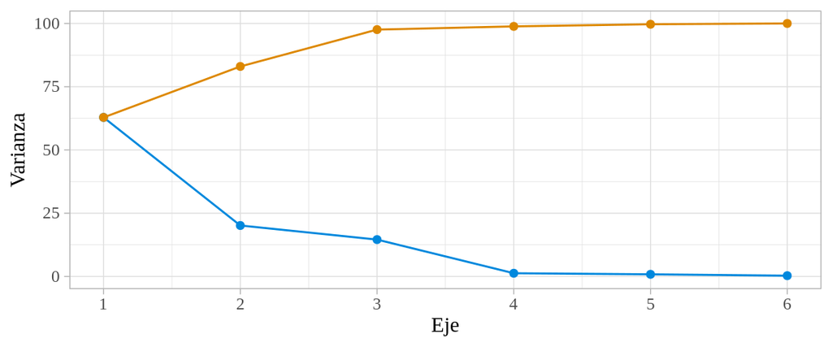

Figura: gráfico de sedimentación de *Identidad social*. En azul el porcentaje de varianza explicado por cada eje, en rojo el porcentaje acumulado. Fuente: elaboración propia utilizando el software estadístico R (R Core Team, 2019).

El círculo de correlaciones permite visualizar los ítems como flechas. Cuando estas flechas apuntan todas en la misma dirección se tiene un nivel de consistencia interna alto.

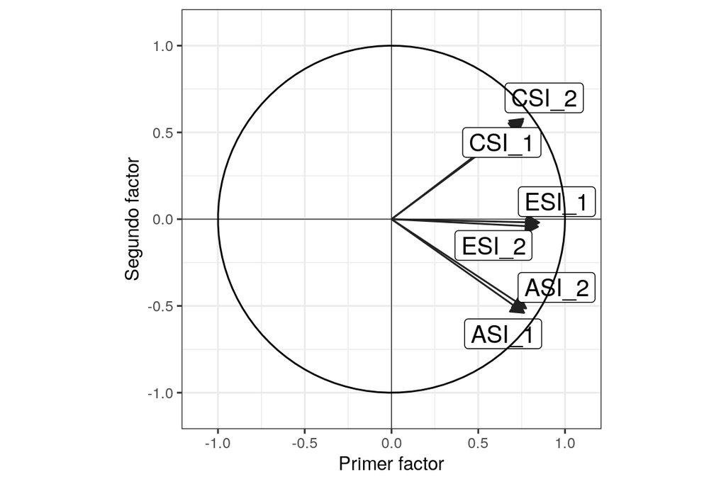

Figura: círculo de correlaciones de *Identidad social*. Fuente: elaboración propia utilizando el software estadístico R (R Core Team, 2019).

#### Análisis de consistencia interna

Para evaluar la consistencia interna es posible usar varios estadísticos. Entre ellos el alpha de Cronbach y el lambda 6 de Guttman; que se muestran a continuación.

Tabla: Alpha de Cronbach y Lambda 6 de Guttman para *Identidad social*. Fuente: elaboración propia.

| Individuos | ítems | Alpha de Cronbach | Guttman’s Lambda 6 |
| --- | --- | --- | --- |
| 120 | 6 | 0.88 | 0.98 |

Para evaluar la pertinencia de los ítems en torno al factor se calcula la consistencia interna retirando los ítems uno por uno. Este análisis del ítem permite medir la consistencia en distintos escenarios y así detectar cuáles ítems resultan inapropiados o afectan la consistencia interna de manera negativa. La siguiente tabla muestra el análisis realizado.

Alpha de Cronbach y Lambda 6 de Guttman retirando cada ítem para *Identidad social*. Fuente: elaboración propia.

| ítems | Individuos | Alpha de Cronbach | Guttman’s Lambda 6 |
| --- | --- | --- | --- |
| CSI_1 | 120 | 0.87 | 0.94 |
| CSI_2 | 120 | 0.87 | 0.94 |
| ASI_1 | 120 | 0.86 | 0.94 |
| ASI_2 | 120 | 0.86 | 0.94 |
| ESI_1 | 120 | 0.85 | 0.93 |
| ESI_2 | 120 | 0.85 | 0.93 |

#### Normalidad del factor

Tabla: Prueba de normalidad de Shapiro-Wilks para *Identidad social*. Fuente: elaboración propia.

| Test statistic | P value |
| --- | --- |
| 0.984 | 0.1673 |

Tabla: Prueba de normalidad de Lilliefors para *Identidad social*. Fuente: elaboración propia.

| Test statistic | P value |
| --- | --- |
| 0.1026 | 0.003443 * * |

### Identificación con la marca

A continuación se muestra el análisis realizado a los ítems asociadas al constructo de Identificación con la marca[^2].

#### Análisis de correlación múltiple

La matriz de correlaciones entre los ítems constituye una primera aproximación. En este gráfico es importante encontrar correlaciones fuertes entre los ítems, al menos mayores a 0.5.

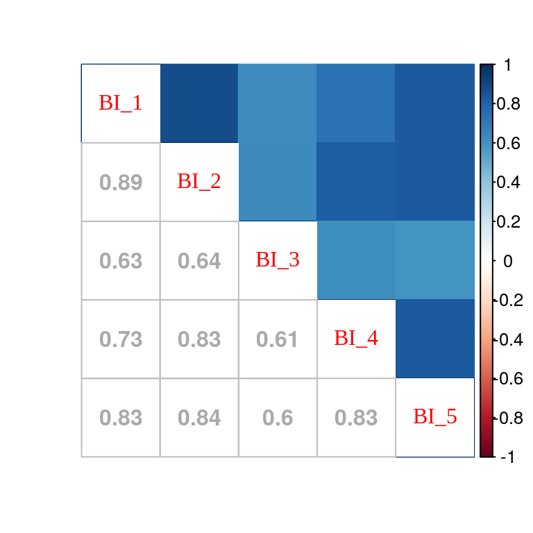

Figura: Matriz de correlaciones de *Identificación con la marca*. Fuente: elaboración propia utilizando el software estadístico R (R Core Team, 2019).

En el análisis de componentes principales cada eje retiene un porcentaje de la varianza. Este es mostrado de manera individual y acumulada en el gráfico de sedimentación.

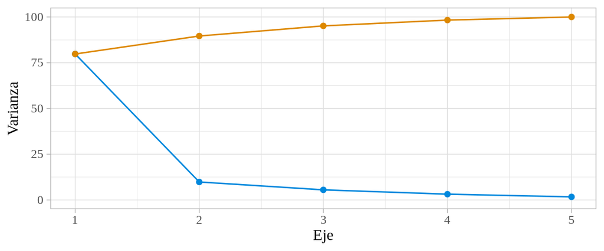

Figura: gráfico de sedimentación de *Identificación con la marca*. En azul el porcentaje de varianza explicado por cada eje, en rojo el porcentaje acumulado. Fuente: elaboración propia utilizando el software estadístico R (R Core Team, 2019).

El círculo de correlaciones permite visualizar los ítems como flechas. Cuando estas flechas apuntan todas en la misma dirección se tiene un nivel de consistencia interna alto.

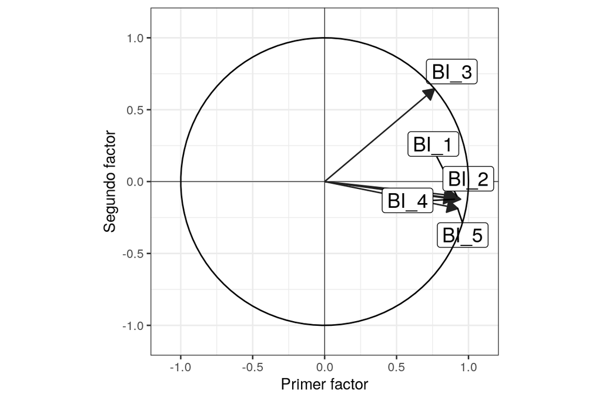

Figura: círculo de correlaciones de *Identificación con la marca*. Fuente: elaboración propia utilizando el software estadístico R (R Core Team, 2019).

#### Análisis de consistencia interna

Para evaluar la consistencia interna es posible usar varios estadísticos. Entre ellos el alpha de Cronbach y el lambda 6 de Guttman; que se muestran a continuación.

Tabla: Alpha de Cronbach y Lambda 6 de Guttman para *Identificación con la marca*. Fuente: elaboración propia.

| Individuos | ítems | Alpha de Cronbach | Guttman’s Lambda 6 |
| --- | --- | --- | --- |
| 120 | 5 | 0.93 | 0.93 |

Para evaluar la pertinencia de los ítems en torno al factor se calcula la consistencia interna retirando los ítems uno por uno. Este análisis del ítem permite medir la consistencia en distintos escenarios y así detectar cuáles ítems resultan inapropiados o afectan la consistencia interna de manera negativa. La siguiente tabla muestra el análisis realizado.

Alpha de Cronbach y Lambda 6 de Guttman retirando cada ítem para *Identificación con la marca*. Fuente: elaboración propia.

| ítems | Individuos | Alpha de Cronbach | Guttman’s Lambda 6 |
| --- | --- | --- | --- |
| BI_1 | 120 | 0.91 | 0.90 |
| BI_2 | 120 | 0.90 | 0.89 |
| BI_3 | 120 | 0.95 | 0.95 |
| BI_4 | 120 | 0.91 | 0.91 |
| BI_5 | 120 | 0.91 | 0.90 |

#### Normalidad del factor

Tabla: Prueba de normalidad de Shapiro-Wilks para *Identificación con la marca*. Fuente: elaboración propia.

| Test statistic | P value |
| --- | --- |
| 0.9719 | 0.01304 * |

Tabla: Prueba de normalidad de Lilliefors para *Identificación con la marca*. Fuente: elaboración propia.

| Test statistic | P value |
| --- | --- |
| 0.0977 | 0.006812 * * |

### Identificación de la comunidad de marca

A continuación se muestra el análisis realizado a los ítems asociadas al constructo de Identificación de la comunidad de marca[^3].

#### Análisis de correlación múltiple

La matriz de correlaciones entre los ítems constituye una primera aproximación. En este gráfico es importante encontrar correlaciones fuertes entre los ítems, al menos mayores a 0.5.

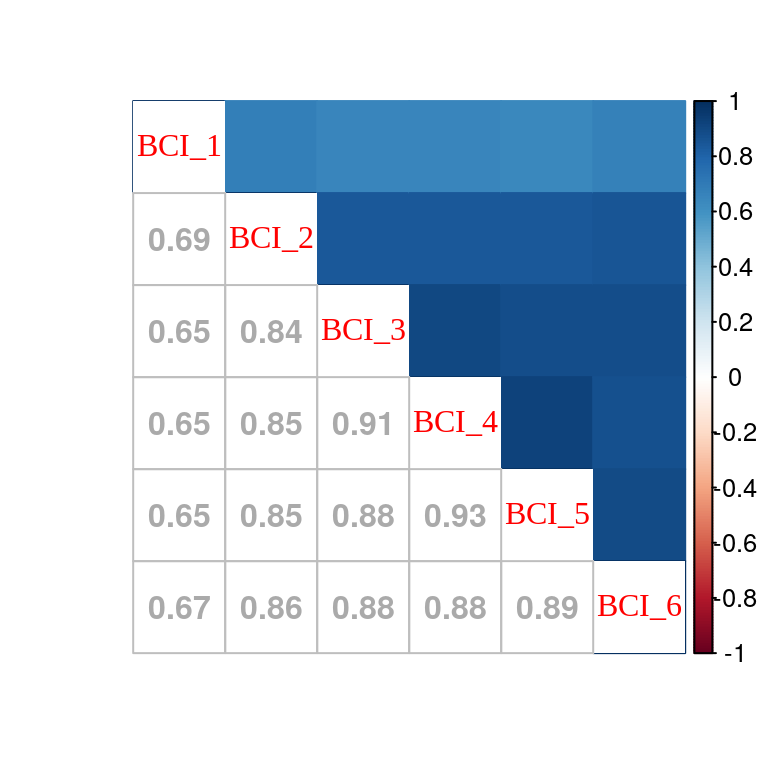

Figura: Matriz de correlaciones de *Identificación de la comunidad de marca*. Fuente: elaboración propia utilizando el software estadístico R (R Core Team, 2019).

En el análisis de componentes principales cada eje retiene un porcentaje de la varianza. Este es mostrado de manera individual y acumulada en el gráfico de sedimentación.

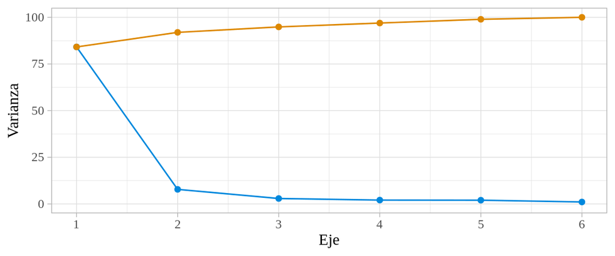

Figura: gráfico de sedimentación de *Identificación de la comunidad de marca*. En azul el porcentaje de varianza explicado por cada eje, en rojo el porcentaje acumulado. Fuente: elaboración propia utilizando el software estadístico R (R Core Team, 2019).

El círculo de correlaciones permite visualizar los ítems como flechas. Cuando estas flechas apuntan todas en la misma dirección se tiene un nivel de consistencia interna alto.

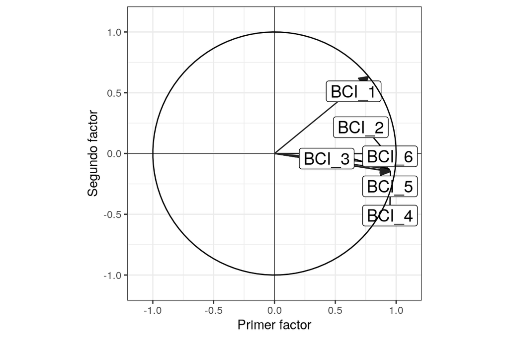

Figura: círculo de correlaciones de *Identificación de la comunidad de marca*. Fuente: elaboración propia utilizando el software estadístico R (R Core Team, 2019).

#### Análisis de consistencia interna

Para evaluar la consistencia interna es posible usar varios estadísticos. Entre ellos el alpha de Cronbach y el lambda 6 de Guttman; que se muestran a continuación.

Tabla: Alpha de Cronbach y Lambda 6 de Guttman para *Identificación de la comunidad de marca*. Fuente: elaboración propia.

| Individuos | ítems | Alpha de Cronbach | Guttman’s Lambda 6 |
| --- | --- | --- | --- |
| 120 | 6 | 0.96 | 0.96 |

Para evaluar la pertinencia de los ítems en torno al factor se calcula la consistencia interna retirando los ítems uno por uno. Este análisis del ítem permite medir la consistencia en distintos escenarios y así detectar cuáles ítems resultan inapropiados o afectan la consistencia interna de manera negativa. La siguiente tabla muestra el análisis realizado.

Alpha de Cronbach y Lambda 6 de Guttman retirando cada ítem para *Identificación de la comunidad de marca*. Fuente: elaboración propia.

| ítems | Individuos | Alpha de Cronbach | Guttman’s Lambda 6 |
| --- | --- | --- | --- |
| BCI_1 | 120 | 0.97 | 0.97 |
| BCI_2 | 120 | 0.95 | 0.95 |
| BCI_3 | 120 | 0.95 | 0.95 |
| BCI_4 | 120 | 0.95 | 0.94 |
| BCI_5 | 120 | 0.95 | 0.94 |
| BCI_6 | 120 | 0.95 | 0.95 |

#### Normalidad del factor

Tabla: Prueba de normalidad de Shapiro-Wilks para *Identificación de la comunidad de marca*. Fuente: elaboración propia.

| Test statistic | P value |
| --- | --- |
| 0.9704 | 0.009571 * * |

Tabla: Prueba de normalidad de Lilliefors para *Identificación de la comunidad de marca*. Fuente: elaboración propia.

| Test statistic | P value |
| --- | --- |
| 0.1015 | 0.004047 * * |

### Voz a voz electrónico

A continuación se muestra el análisis realizado a los ítems asociadas al constructo de Voz a voz electrónico[^4].

#### Análisis de correlación múltiple

La matriz de correlaciones entre los ítems constituye una primera aproximación. En este gráfico es importante encontrar correlaciones fuertes entre los ítems, al menos mayores a 0.5.

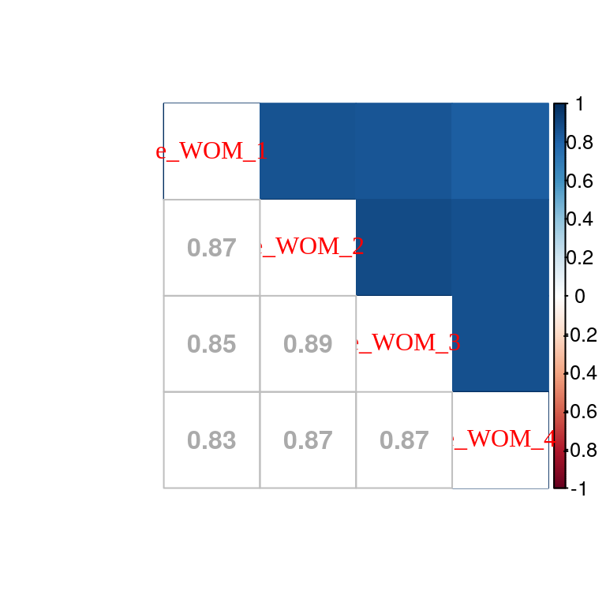

Figura: Matriz de correlaciones de *Voz a voz electrónico*. Fuente: elaboración propia utilizando el software estadístico R (R Core Team, 2019).

En el análisis de componentes principales cada eje retiene un porcentaje de la varianza. Este es mostrado de manera individual y acumulada en el gráfico de sedimentación.

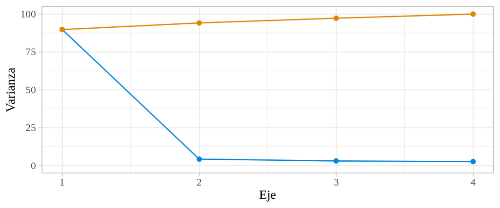

Figura: gráfico de sedimentación de *Voz a voz electrónico*. En azul el porcentaje de varianza explicado por cada eje, en rojo el porcentaje acumulado. Fuente: elaboración propia utilizando el software estadístico R (R Core Team, 2019).

El círculo de correlaciones permite visualizar los ítems como flechas. Cuando estas flechas apuntan todas en la misma dirección se tiene un nivel de consistencia interna alto.

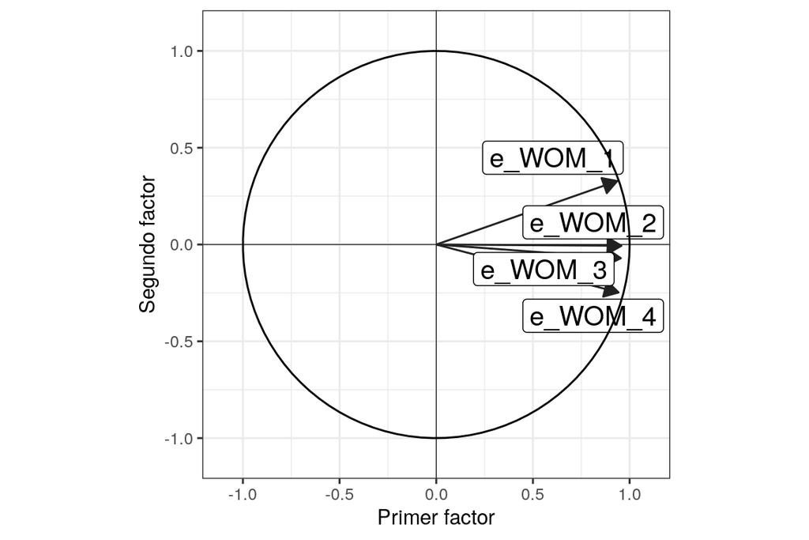

Figura: círculo de correlaciones de *Voz a voz electrónico*. Fuente: elaboración propia utilizando el software estadístico R (R Core Team, 2019).

#### Análisis de consistencia interna

Para evaluar la consistencia interna es posible usar varios estadísticos. Entre ellos el alpha de Cronbach y el lambda 6 de Guttman; que se muestran a continuación.

Tabla: Alpha de Cronbach y Lambda 6 de Guttman para *Voz a voz electrónico*. Fuente: elaboración propia.

| Individuos | ítems | Alpha de Cronbach | Guttman’s Lambda 6 |
| --- | --- | --- | --- |
| 120 | 4 | 0.96 | 0.95 |

Para evaluar la pertinencia de los ítems en torno al factor se calcula la consistencia interna retirando los ítems uno por uno. Este análisis del ítem permite medir la consistencia en distintos escenarios y así detectar cuáles ítems resultan inapropiados o afectan la consistencia interna de manera negativa. La siguiente tabla muestra el análisis realizado.

Alpha de Cronbach y Lambda 6 de Guttman retirando cada ítem para *Voz a voz electrónico*. Fuente: elaboración propia.

| ítems | Individuos | Alpha de Cronbach | Guttman’s Lambda 6 |
| --- | --- | --- | --- |
| e_WOM_1 | 120 | 0.96 | 0.94 |
| e_WOM_2 | 120 | 0.95 | 0.92 |
| e_WOM_3 | 120 | 0.95 | 0.92 |
| e_WOM_4 | 120 | 0.95 | 0.93 |

#### Normalidad del factor

Tabla: Prueba de normalidad de Shapiro-Wilks para *Voz a voz electrónico*. Fuente: elaboración propia.

| Test statistic | P value |
| --- | --- |
| 0.9343 | 1.791e-05 * * * |

Tabla: Prueba de normalidad de Lilliefors para *Voz a voz electrónico*. Fuente: elaboración propia.

| Test statistic | P value |
| --- | --- |
| 0.2209 | 8.181e-16 * * * |

# Modelo

En esta sección se presentan los resultados del cálculo del modelo de ecuaciones estructurales propuesto.

En primera instancia se observa los valores estimados vía máxima verosimilitud con p valores e intervalos de confianza obtenidos bajo el supuesto de normalidad. Se realizan tres tipos de estimaciones: la estimación de los pesos correspondientes a las relaciones explícitas del modelo; la estimación de las correlaciones entre los constructos no conectados y la estimación de las varianzas de cada variable (sea observada o latente).

Estos p valores e intervalos de confianza han sido calculados usando el supuesto de normalidad de las variables latentes. Sin embargo, según las pruebas realizadas previamente este supuesto no se cumple. De manera que es necesario recalcular los p valores e intervalos de confianza: para ello se realiza un procedimiento de bootstrapping.

Seguido a esto se realiza la evaluación del modelo, calculando diversos estadísticos que dan cuenta de distintos factores relevantes. Se evalúa consistencia, significancia y ajuste.

Estos procedimientos permiten evaluar las hipótesis planteadas en el dearrollo del estudio y presentar el modelo mediante visualizaciones adecuadas.

## Estimaciones del modelo

En la primera tabla se presenta la información de los estimadores correspondientes a las variables latentes.

Tabla: Estimadores de coeficientes calculados en el modelo. Fuente: elaboración propia.

| estimate | value | se | z | pvalue | ci.lower | ci.upper |
| --- | --- | --- | --- | --- | --- | --- |
| BCI=~BCI_1 | 1.00 | 0.00 | - | - | 1.00 | 1.00 |
| BCI=~BCI_2 | 1.13 | 0.11 | 10.03 | 0.00 | 0.91 | 1.35 |
| BCI=~BCI_3 | 1.22 | 0.12 | 10.45 | 0.00 | 0.99 | 1.45 |
| BCI=~BCI_4 | 1.16 | 0.11 | 10.63 | 0.00 | 0.95 | 1.38 |
| BCI=~BCI_5 | 1.14 | 0.11 | 10.70 | 0.00 | 0.93 | 1.35 |
| BCI=~BCI_6 | 1.14 | 0.11 | 10.50 | 0.00 | 0.93 | 1.35 |
| BCI=~e_WOM | -12.32 | 25.66 | -0.48 | 0.63 | -62.61 | 37.98 |
| BI=~BI_1 | 1.00 | 0.00 | - | - | 1.00 | 1.00 |
| BI=~BI_2 | 0.98 | 0.06 | 16.19 | 0.00 | 0.86 | 1.10 |
| BI=~BI_3 | 0.90 | 0.10 | 9.14 | 0.00 | 0.71 | 1.10 |
| BI=~BI_4 | 1.02 | 0.07 | 15.07 | 0.00 | 0.89 | 1.15 |
| BI=~BI_5 | 1.04 | 0.06 | 16.89 | 0.00 | 0.92 | 1.16 |
| BI=~BCI | 0.95 | 0.10 | 9.78 | 0.00 | 0.76 | 1.14 |
| BI=~e_WOM | 12.12 | 24.12 | 0.50 | 0.62 | -35.15 | 59.39 |
| e_WOM=~e_WOM_1 | 1.00 | 0.00 | - | - | 1.00 | 1.00 |
| e_WOM=~e_WOM_2 | 1.03 | 0.06 | 18.59 | 0.00 | 0.92 | 1.14 |
| e_WOM=~e_WOM_3 | 1.09 | 0.06 | 17.99 | 0.00 | 0.97 | 1.20 |
| e_WOM=~e_WOM_4 | 1.03 | 0.06 | 17.04 | 0.00 | 0.91 | 1.15 |
| SI=~CSI_1 | 1.00 | 0.00 | - | - | 1.00 | 1.00 |
| SI=~CSI_2 | 1.03 | 0.23 | 4.51 | 0.00 | 0.58 | 1.48 |
| SI=~ASI_1 | 1.16 | 0.26 | 4.53 | 0.00 | 0.66 | 1.66 |
| SI=~ASI_2 | 1.15 | 0.25 | 4.52 | 0.00 | 0.65 | 1.65 |
| SI=~ESI_1 | 2.12 | 0.34 | 6.18 | 0.00 | 1.45 | 2.80 |
| SI=~ESI_2 | 2.12 | 0.34 | 6.17 | 0.00 | 1.45 | 2.79 |
| SI=~BCI | -0.03 | 0.05 | -0.52 | 0.60 | -0.13 | 0.08 |

En la segunda tabla se presenta la información de las covarianzas estimadas.

Tabla: Estimadores de covarianza calculados en el modelo. Fuente: elaboración propia.

| estimate | value | se | z | pvalue | ci.lower | ci.upper |
| --- | --- | --- | --- | --- | --- | --- |
| BI~~SI | 0.19 | 0.05 | 3.92 | 0 | 0.1 | 0.29 |

En la tercera tabla se presenta la información de las varianzas estimadas.

Tabla: Estimadores de varianza calculados en el modelo. Fuente: elaboración propia.

| estimate | value | se | z | pvalue | ci.lower | ci.upper |
| --- | --- | --- | --- | --- | --- | --- |
| BCI_1 | 0.63 | 0.08 | 7.62 | 0.00 | 0.47 | 0.79 |
| BCI_2 | 0.20 | 0.03 | 7.24 | 0.00 | 0.15 | 0.26 |
| BCI_3 | 0.14 | 0.02 | 6.91 | 0.00 | 0.10 | 0.19 |
| BCI_4 | 0.10 | 0.01 | 6.62 | 0.00 | 0.07 | 0.13 |
| BCI_5 | 0.08 | 0.01 | 6.47 | 0.00 | 0.06 | 0.11 |
| BCI_6 | 0.12 | 0.02 | 6.85 | 0.00 | 0.09 | 0.15 |
| BI_1 | 0.20 | 0.03 | 7.27 | 0.00 | 0.14 | 0.25 |
| BI_2 | 0.14 | 0.02 | 7.08 | 0.00 | 0.10 | 0.18 |
| BI_3 | 0.72 | 0.09 | 7.65 | 0.00 | 0.53 | 0.90 |
| BI_4 | 0.21 | 0.03 | 7.28 | 0.00 | 0.15 | 0.26 |
| BI_5 | 0.13 | 0.02 | 6.89 | 0.00 | 0.09 | 0.16 |
| e_WOM_1 | 0.14 | 0.02 | 6.40 | 0.00 | 0.10 | 0.18 |
| e_WOM_2 | 0.07 | 0.01 | 5.03 | 0.00 | 0.05 | 0.10 |
| e_WOM_3 | 0.10 | 0.02 | 5.52 | 0.00 | 0.07 | 0.14 |
| e_WOM_4 | 0.12 | 0.02 | 6.07 | 0.00 | 0.08 | 0.16 |
| CSI_1 | 0.50 | 0.06 | 7.72 | 0.00 | 0.37 | 0.63 |
| CSI_2 | 0.48 | 0.06 | 7.72 | 0.00 | 0.35 | 0.60 |
| ASI_1 | 0.59 | 0.08 | 7.72 | 0.00 | 0.44 | 0.74 |
| ASI_2 | 0.59 | 0.08 | 7.72 | 0.00 | 0.44 | 0.74 |
| ESI_1 | 0.01 | 0.01 | 1.03 | 0.30 | -0.01 | 0.03 |
| ESI_2 | 0.02 | 0.01 | 2.09 | 0.04 | 0.00 | 0.04 |
| BCI | 0.00 | 0.00 | -0.51 | 0.61 | -0.01 | 0.01 |
| BI | 0.76 | 0.12 | 6.27 | 0.00 | 0.52 | 1.00 |
| e_WOM | 0.81 | 0.85 | 0.94 | 0.35 | -0.87 | 2.48 |
| SI | 0.16 | 0.06 | 2.88 | 0.00 | 0.05 | 0.27 |

## Bootstraping

Como se vio en las pruebas de normalidad de cada factor, el supuesto de normalidad del modelo en general no se cumple. Este defecto se suple calculando la significancia de los coeficientes mediante un proceso de bootstrapping.

Tabla: Estimadores y cuantiles vía bootstrapping. Fuente: elaboración propia.

| estimate | value | se | min | q02.5 | q50 | q97.5 | max | pvalue |
| --- | --- | --- | --- | --- | --- | --- | --- | --- |
| BCI=~BCI_2 | 1.11 | 0.09 | 1.03 | 1.03 | 1.06 | 1.23 | 1.23 | 0.00 |
| BCI=~BCI_3 | 1.23 | 0.06 | 1.16 | 1.16 | 1.20 | 1.33 | 1.34 | 0.00 |
| BCI=~BCI_4 | 1.16 | 0.06 | 1.10 | 1.10 | 1.13 | 1.28 | 1.29 | 0.00 |
| BCI=~BCI_5 | 1.14 | 0.08 | 1.06 | 1.06 | 1.11 | 1.26 | 1.28 | 0.00 |
| BCI=~BCI_6 | 1.14 | 0.08 | 1.05 | 1.05 | 1.13 | 1.22 | 1.22 | 0.00 |
| BCI=~e_WOM | -3.39 | 0.96 | -4.57 | -4.51 | -3.39 | -2.12 | -2.12 | 0.00 |
| BI=~BCI | 0.95 | 0.08 | 0.84 | 0.84 | 0.96 | 1.03 | 1.03 | 0.00 |
| BI=~BI_2 | 0.99 | 0.08 | 0.90 | 0.90 | 0.99 | 1.09 | 1.10 | 0.00 |
| BI=~BI_3 | 0.90 | 0.09 | 0.78 | 0.78 | 0.89 | 1.00 | 1.00 | 0.00 |
| BI=~BI_4 | 0.99 | 0.05 | 0.90 | 0.91 | 1.01 | 1.05 | 1.05 | 0.00 |
| BI=~BI_5 | 1.02 | 0.06 | 0.95 | 0.95 | 1.01 | 1.10 | 1.11 | 0.00 |
| BI=~e_WOM | 3.72 | 1.12 | 2.20 | 2.26 | 3.87 | 5.18 | 5.28 | 0.00 |
| e_WOM=~e_WOM_2 | 1.05 | 0.04 | 0.98 | 0.98 | 1.05 | 1.10 | 1.11 | 0.00 |
| e_WOM=~e_WOM_3 | 1.10 | 0.08 | 0.97 | 0.98 | 1.11 | 1.20 | 1.21 | 0.00 |
| e_WOM=~e_WOM_4 | 1.04 | 0.04 | 1.00 | 1.01 | 1.02 | 1.11 | 1.12 | 0.00 |
| SI=~ASI_1 | 1.18 | 0.32 | 0.77 | 0.79 | 1.17 | 1.69 | 1.75 | 0.00 |
| SI=~ASI_2 | 1.20 | 0.31 | 0.86 | 0.87 | 1.18 | 1.73 | 1.80 | 0.00 |
| SI=~BCI | -0.05 | 0.06 | -0.14 | -0.13 | -0.06 | 0.05 | 0.06 | 0.29 |
| SI=~CSI_2 | 1.03 | 0.05 | 0.98 | 0.98 | 1.02 | 1.12 | 1.12 | 0.00 |
| SI=~ESI_1 | 2.17 | 0.37 | 1.79 | 1.80 | 2.02 | 2.73 | 2.78 | 0.00 |
| SI=~ESI_2 | 2.17 | 0.39 | 1.76 | 1.77 | 2.03 | 2.75 | 2.81 | 0.00 |

## Ajuste

Los estadísticos presentados dan cuenta de diferentes características del modelo, entre ellas parsimonia, significancia y ajuste.

Tabla: Estadísticos de bondad de ajuste del modelo. Fuente: Elaboracion propia.

| estimate | value |
| --- | --- |
| npar | 47.0000 |
| fmin | 4.3052 |
| chisq | 1033.2595 |
| df | 184.0000 |
| pvalue | 0.0000 |
| baseline.chisq | 4001.2143 |
| baseline.df | 210.0000 |
| baseline.pvalue | 0.0000 |
| cfi | 0.7760 |
| tli | 0.7443 |
| nnfi | 0.7443 |
| rfi | 0.7053 |
| nfi | 0.7418 |
| pnfi | 0.6499 |
| ifi | 0.7775 |
| rni | 0.7760 |
| logl | -1955.9852 |
| unrestricted.logl | -1439.3555 |
| aic | 4005.9704 |
| bic | 4136.9825 |
| ntotal | 120.0000 |
| bic2 | 3988.3908 |
| rmsea | 0.1961 |
| rmsea.ci.lower | 0.1846 |
| rmsea.ci.upper | 0.2079 |
| rmsea.pvalue | 0.0000 |
| rmr | 0.1209 |
| rmr_nomean | 0.1209 |
| srmr | 0.1366 |
| srmr_bentler | 0.1366 |
| srmr_bentler_nomean | 0.1366 |
| crmr | 0.1433 |
| crmr_nomean | 0.1433 |
| srmr_mplus | 0.1366 |
| srmr_mplus_nomean | 0.1366 |
| cn_05 | 26.1611 |
| cn_01 | 27.8909 |
| gfi | 0.6404 |
| agfi | 0.5485 |
| pgfi | 0.5101 |
| mfi | 0.0291 |
| ecvi | 9.3938 |

## Hipótesis

Tabla: Evaluación de las hipótesis del estudio. Fuente: Elaboracion propia.

| hyp | estimate | number | pvalue |
| --- | --- | --- | --- |
| H3 | BCI=~e_WOM | -12.32 | 0.0000 |
| H2 | BI=~BCI | 0.95 | 0.0000 |
| H4 | BI=~e_WOM | 12.12 | 0.0000 |
| H1 | SI=~BCI | -0.03 | 0.2857 |

## Visualización

Se muestran a continuación algunos gráficos relativos al modelo. En ambas visualizaciones se observan los pesos que tienen las distinas variables en relación a los constructos y los constructos entre ellos.

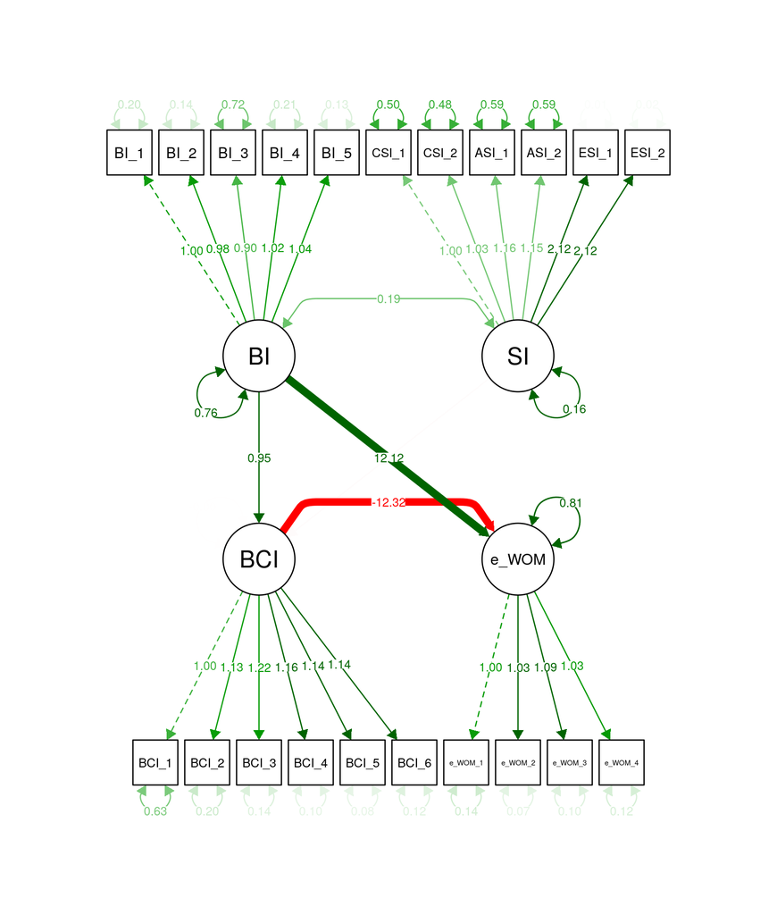

Figura: Diagrama del modelo. Fuente: elaboración propia utilizando el software estadístico R (R Core Team, 2019).

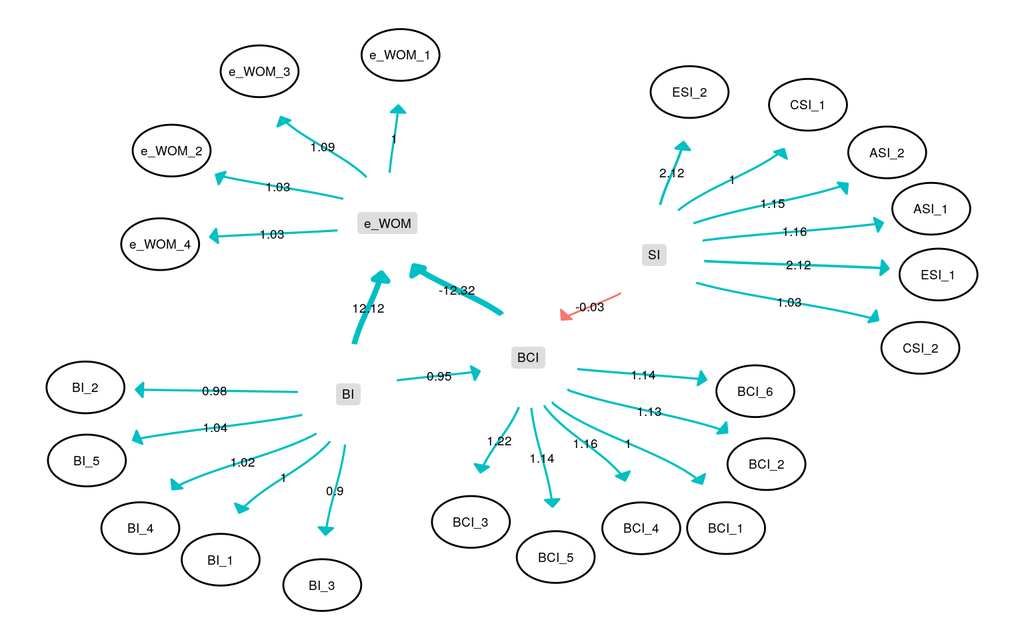

Figura: Diagrama del modelo. Fuente: elaboración propia utilizando el software estadístico R (R Core Team, 2019).

# Referencias

Cronbach, L. J. (1951). Coefficient alpha and the internal structure of tests. *Psychometrika*, *16*(3), 297–334. http://doi.org/10.1007/BF02310555

Jolliffe, I. T. (2002). *Principal Component Analysis, Second Edition* (Vol. 30, p. 487). http://doi.org/10.2307/1270093

R Core Team. (2019). *R: A language and environment for statistical computing*. Vienna, Austria: R Foundation for Statistical Computing. Retrieved from https://www.R-project.org/

[^1]: CSI_1: Identidad social cognitiva 1. CSI_2: Identidad social cognitiva 2. ASI_1: Identidas social afectiva 1. ASI_2: Identidad social afectiva 2. ESI_1: Identidad social evaluativa 1. ESI_2: Identidad social evaluativa 2
[^2]: BI_1: Identificación con la marca 1. BI_2: Identificación con la marca 2. BI_3: Identificación con la marca 3. BI_4: Identificación con la marca 4. BI_5: Identificación con la marca 5
[^3]: BCI_1: Identificación de la comunidad de marca 1. BCI_2: Identificación de la comunidad de marca 2. BCI_3: Identificación de la comunidad de marca 3. BCI_4: Identificación de la comunidad de marca 4. BCI_5: Identificación de la comunidad de marca 5. BCI_6: Identificación de la comunidad de marca 6
[^4]: e_WOM_1: Voz a voz electrónico 1. e_WOM_2: Voz a voz electrónico 2. e_WOM_3: Voz a voz electrónico 3. e_WOM_4: Voz a voz electrónico 4